# Notebook 07 – Solutions

## Getting Started

Before running this notebook, select “Session > Restart R and Clear Output” in the menu above to start a new R session. This will clear any old data sets and give us a blank slate to start with.

After starting a new session, run the following code chunk to load the libraries and data that we will be working with today.

I have set the options `include=FALSE` and `message=FALSE` to avoid cluttering the solutions with all the output from this code.

## Practice

### Movies data

For this notebook, we will be creating a dataset, reading it into R, and producing a couple of different data visualizations.

We will create a dataset as a class describing a set of movies. Each student will be tasked with creating three rows of data. We will record the following items in the GoogleSheets file linked to on the class website:

- student number
- title
- year of release
- budget
- box-office, total amount of money
- genre
- personal rating of the film, from 1-5 stars

Once you are finished, save the data set as a csv file, upload it to the “data” directory in RStudio, change its name, and read it into R in the following block of code:

```r
movies <- read_csv("../data/movies.csv")
movies
```

```
## # A tibble: 129 × 8
##    student_number section title         year_release budget box_office genre
##             <dbl>   <dbl> <chr>                <dbl>  <dbl>      <dbl> <chr>
##  1              1       1 Arrival               2016 4.70e7  100500000 Sci-…
##  2              1       1 The Holiday           2006 8.5 e7  205800000 Roma…
##  3              1       1 The Last Sam…         2003 1.4 e8  456800000 Drama
##  4              2       1 The Social N…         2010 4   e7  224900000 Biog…
##  5              2       1 Steve Jobs            2015 3   e7   34000000 Biog…
##  6              3       1 Shrek                 2001 6   e7  487900000 Come…
##  7              3       1 Bee Movie             2007 1.5 e8  293500000 Come…
##  8              3       1 Citizen Kane          1941 8.40e5    1800000 Drama
##  9              4       1 Airplane!             1980 3.5 e7  171000000 Trag…
## 10              4       1 Dr. Strangel…         1964 1.80e6    9200000 Come…
## # ℹ 119 more rows
## # ℹ 1 more variable: personal_rating <dbl>
```

Then, produce a scatterplot below with the budget on the x-axis, box-office numbers on the y-axis, points colored by the year of release, and the size of the points corresponding to your personal rating. Use a text repel layer to label the movies by their title.

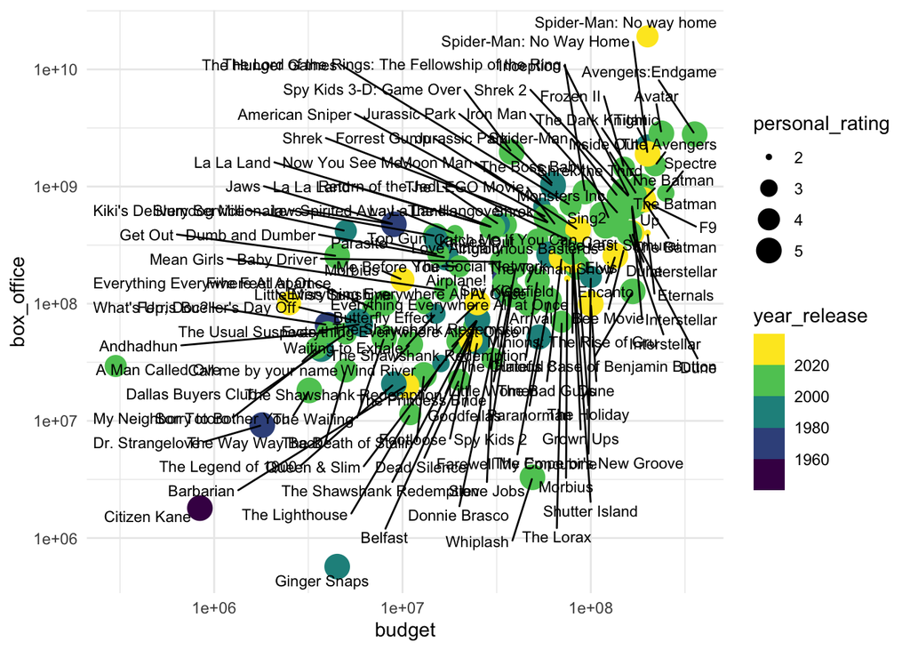

```r
# Question 01
movies |>
  ggplot(aes(budget, box_office)) +
    geom_point(aes(color = year_release, size = personal_rating)) +
    geom_text_repel(aes(label = title), size = 3) +
    scale_x_log10() +
    scale_y_log10() +
    scale_color_viridis_b()
```

If you think it is needed, also include logarithmic scales for the x- and y-axes.

### Labels and Themes

For the last few questions, let’s finish a few loose ends about how to make data visualizations in R. The function `labs()` is an important element that can be added to any ggplot graphic. Inside the `labs()` function, you can set aesthetics from the plot equal to a string to change the corresponding label in the plot. For example, adding `labs(x = "HELLO!")` will change the label of the x-axis to the string “HELLO!”. In the code below, take the previous code from above and add an appropriate label to the x-axis.

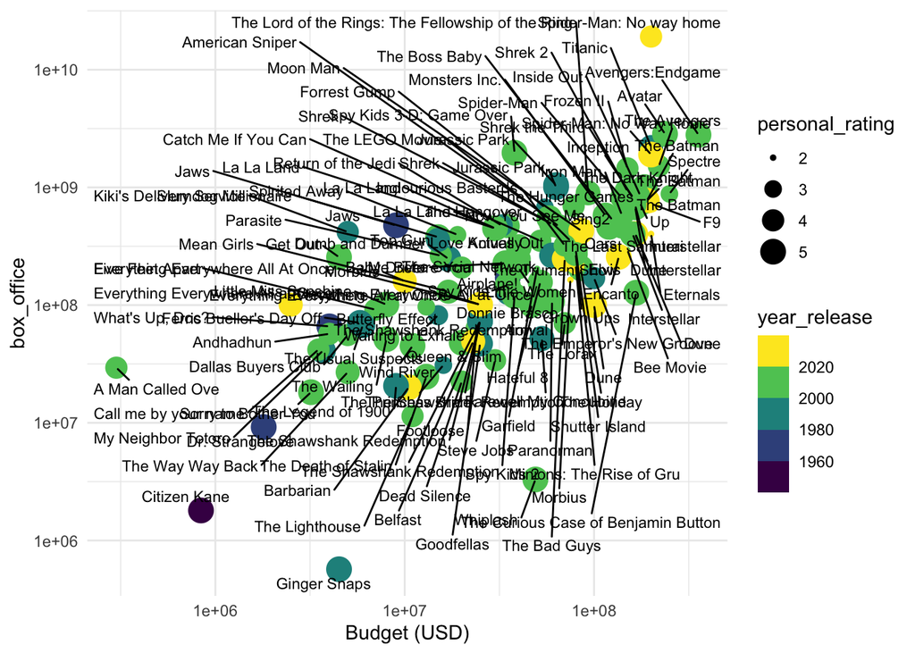

```r
# Question 02
movies |>
  ggplot(aes(budget, box_office)) +
    geom_point(aes(color = year_release, size = personal_rating)) +
    geom_text_repel(aes(label = title), size = 3) +
    scale_x_log10() +
    scale_y_log10() +
    scale_color_viridis_b() +
    labs(x = "Budget (USD)")
```

Now, copy the code above and in the next block add appropriate labels for the y-axis, the color aesthetic, and the size aesthetic.

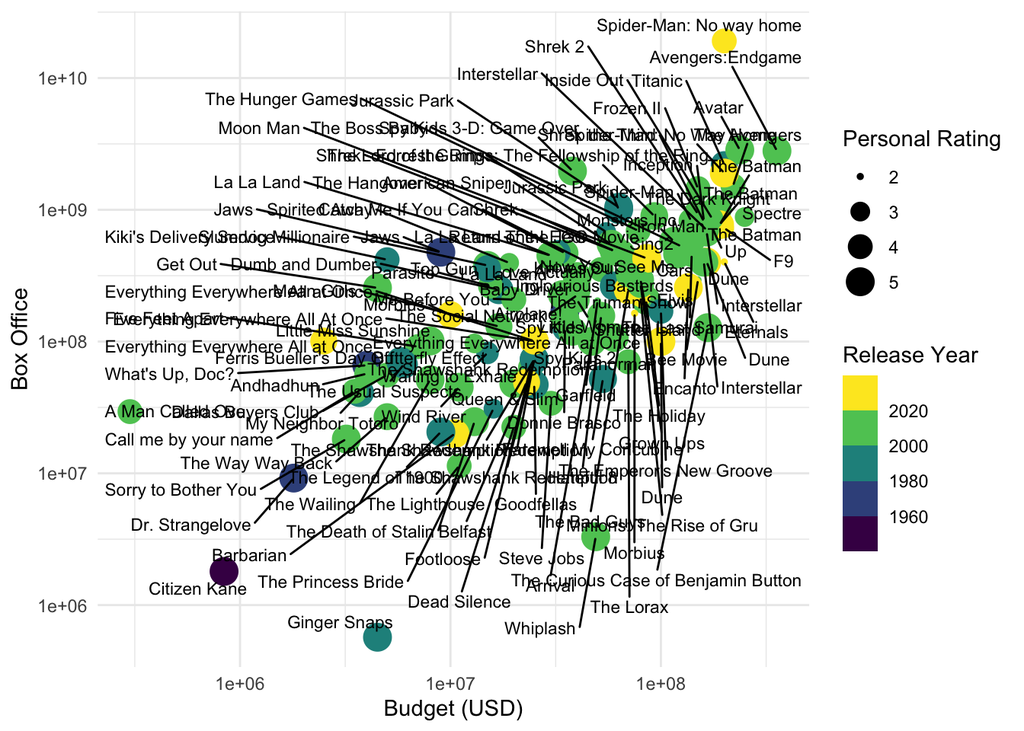

```r
# Question 03
movies |>
  ggplot(aes(budget, box_office)) +
    geom_point(aes(color = year_release, size = personal_rating)) +
    geom_text_repel(aes(label = title), size = 3) +
    scale_x_log10() +
    scale_y_log10() +
    scale_color_viridis_b() +
    labs(x = "Budget (USD)", y = "Box Office", color = "Release Year",
         size = "Personal Rating")
```

There are three special additional elements that we can set inside of `labs()` called `title` (the main title of the plot), `subtitle`, and `caption` (the description at the bottom of the plot). Take the code above and add a title, subtitle, and caption.

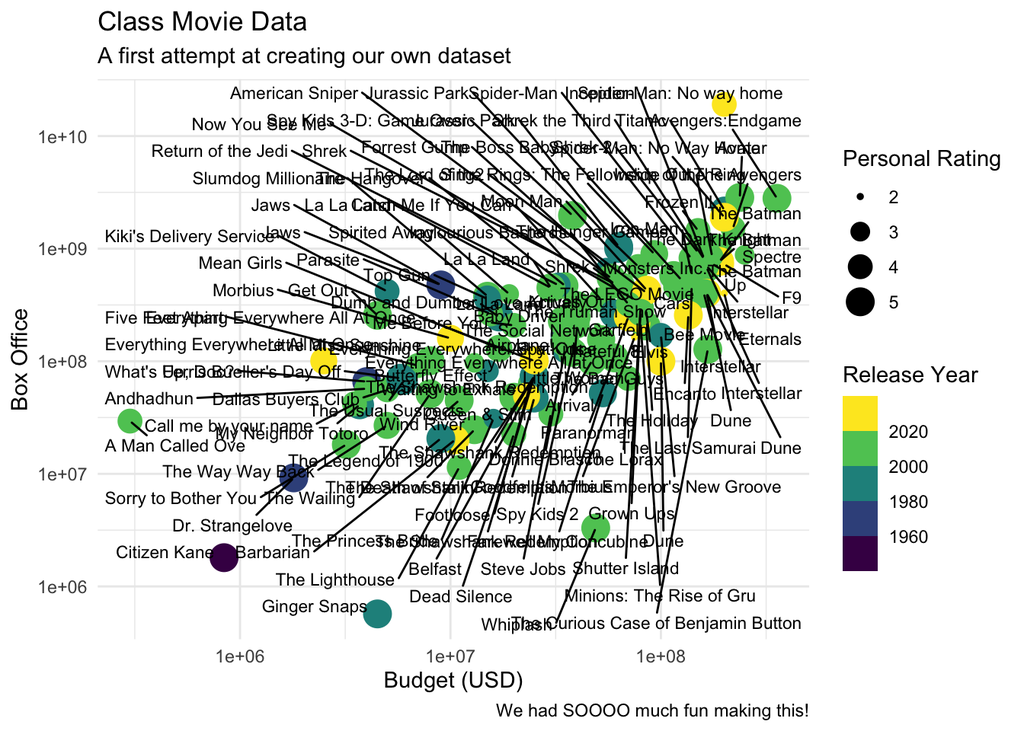

```r
# Question 04
movies |>
  ggplot(aes(budget, box_office)) +
    geom_point(aes(color = year_release, size = personal_rating)) +
    geom_text_repel(aes(label = title), size = 3) +
    scale_x_log10() +
    scale_y_log10() +
    scale_color_viridis_b() +
    labs(x = "Budget (USD)", y = "Box Office", color = "Release Year",
         size = "Personal Rating", title = "Class Movie Data",
         subtitle = "A first attempt at creating our own dataset",
         caption = "We had SOOOO much fun making this!")
```

As a final step, we can add another element called a theme to change the additional visual elements of the plot, such as what fonts are used in the labels, and what colors are used in the interior parts of the graphic. The default that I have set for you in class is called `theme_minimal()`. It’s great for a first-pass of some graphics. In the plot below, copy your graphic from above and add one final element called `theme_tufte()`.

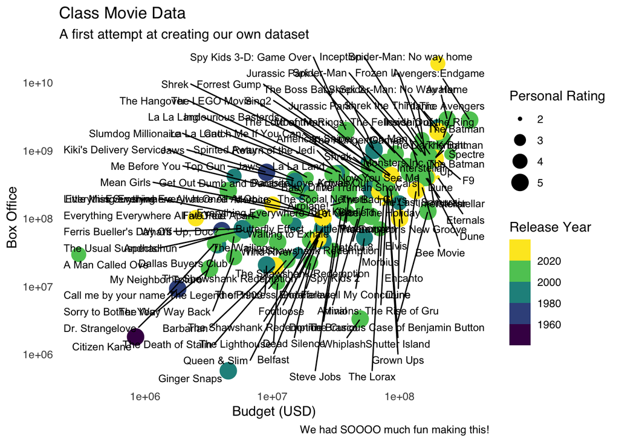

```r
# Question 05
movies |>
  ggplot(aes(budget, box_office)) +
    geom_point(aes(color = year_release, size = personal_rating)) +
    geom_text_repel(aes(label = title), size = 3) +
    scale_x_log10() +
    scale_y_log10() +
    scale_color_viridis_b() +
    labs(x = "Budget (USD)", y = "Box Office", color = "Release Year",
         size = "Personal Rating", title = "Class Movie Data",
         subtitle = "A first attempt at creating our own dataset",
         caption = "We had SOOOO much fun making this!") +
    theme_tufte()
```

I like this theme a lot for creating graphics for publication because it is very clean and avoids using extra ink that I can make better use of with manual annotations. There are more other themes and theme options that you can read about the R documentation to change the way a ggplot object looks. Several other R packages also provide additional themes ready to use out of the box.